# Milestone Report

Pingping

8/26/2020

## Load and clean the data

First, if the data doesn’t exist in the local file, we’ll download the data from the following website: https://d396qusza40orc.cloudfront.net/dsscapstone/dataset/Coursera-SwiftKey.zip.

```r
dataurl <- "https://d396qusza40orc.cloudfront.net/dsscapstone/dataset/Coursera-SwiftKey.zip"
# if data doesn't exist, download the data and unzip
if (!file.exists("Coursera-SwiftKey.zip")) {
  download.file(dataurl)
  unzip("Coursera-SwiftKey.zip")
}
# load the data in the en_US, there are three of datasets
blogs <- readLines("final/en_US/en_US.blogs.txt", encoding = "UTF-8", skipNul = T)
news <- readLines("final/en_US/en_US.news.txt", encoding = "UTF-8", skipNul = T)
twitter <- readLines("final/en_US/en_US.twitter.txt", encoding = "UTF-8", skipNul = T)
```

Here’s some basic information about the datasets:

```r
library(stringi)
blogsize <- file.size("final/en_US/en_US.blogs.txt")/1024/1024
newsize <- file.size("final/en_US/en_US.news.txt")/1024/1024
twittersize <- file.size("final/en_US/en_US.twitter.txt")/1024/1024
bloglength <- length(blogs)
newslength <- length(news)
twitterlength <- length(twitter)
blogsword <- sum(stri_count_words(blogs))
newsword <- sum(stri_count_words(news))
twitterword <- sum(stri_count_words(twitter))
file <- c("blogs", "news", "twitter")
size_MB <- c(blogsize, newsize, twittersize)
length <- c(bloglength, newslength, twitterlength)
word <- c(blogsword, newsword, twitterword)
basicinfo <- data.frame(file, size_MB, length, word)
basicinfo
```

```
##      file  size_MB  length     word
## 1   blogs 200.4242  899288 37546239
## 2    news 196.2775   77259  2674536
## 3 twitter 159.3641 2360148 30093413
```

## Data sampling

Considering that the file is too large, we’ll take a small sample (1%) to analyze the data.

```r
set.seed(1234)
data.sample <- c(sample(blogs, length(blogs) * 0.01),
                 sample(news, length(news) * 0.01),
                 sample(twitter, length(twitter) * 0.01))
saveRDS(data.sample, 'sample.rds')
```

Now we have a single data.sample that includes the data from the blogs, news and twitter files.

## Data cleaning

```r
sampledata <- readRDS("sample.rds")
# Create a Corpus
docs <- VCorpus(VectorSource(sampledata))
# clean the data
docs <- tm_map(docs, tolower) #change all letters to lower
docs <- tm_map(docs, removePunctuation) #remove the punctuation
docs <- tm_map(docs, removeNumbers) #remove numbers
docs <- tm_map(docs, removeWords, stopwords("english")) #remove non-English words
docs <- tm_map(docs, PlainTextDocument) #create plain text documents
docs <- tm_map(docs, stemDocument) #stem words in a text document
docs <- tm_map(docs, stripWhitespace) #multiple whitespace characters are collapsed to a single blank
```

Now we have got a cleaner data for analyzation.

## N-gram Tokenization

We’ll start creat the N-gram Tokenization to find the most frequent word or phrases used in the data.

```r
#Creat N-gram Tokenization
singlegram <- function(x) NGramTokenizer(x, Weka_control(min = 1, max = 1)) #single word
bigram <- function(x) NGramTokenizer(x, Weka_control(min = 2, max = 2)) #two words
trigram <- function(x) NGramTokenizer(x, Weka_control(min = 3, max = 3)) #three words

# Create TermDocumentMatrix with Tokenizations and Remove Sparse Terms
freq1 <- removeSparseTerms(TermDocumentMatrix(docs, control = list(tokenize = singlegram)), 0.9999)
freq2 <- removeSparseTerms(TermDocumentMatrix(docs, control = list(tokenize = bigram)), 0.9999)
freq3 <- removeSparseTerms(TermDocumentMatrix(docs, control = list(tokenize = trigram)), 0.9999)

# Create frequencies and sort the words
single_freq <- sort(rowSums(as.matrix(freq1)), decreasing=TRUE)
bi_freq <- sort(rowSums(as.matrix(freq2)), decreasing=TRUE)
tri_freq <- sort(rowSums(as.matrix(freq3)), decreasing=TRUE)

# Create DataFrames
single_df <- data.frame(term=names(single_freq), freq=as.vector(single_freq))
bi_df <- data.frame(term=names(bi_freq), freq= as.vector(bi_freq))
tri_df <- data.frame(term=names(tri_freq), freq=as.vector(tri_freq))
```

We have got the most frequently used single words, biword and triword phrases.

## Exploratory Analysis

The top 20 fequently used single words are shown as below:

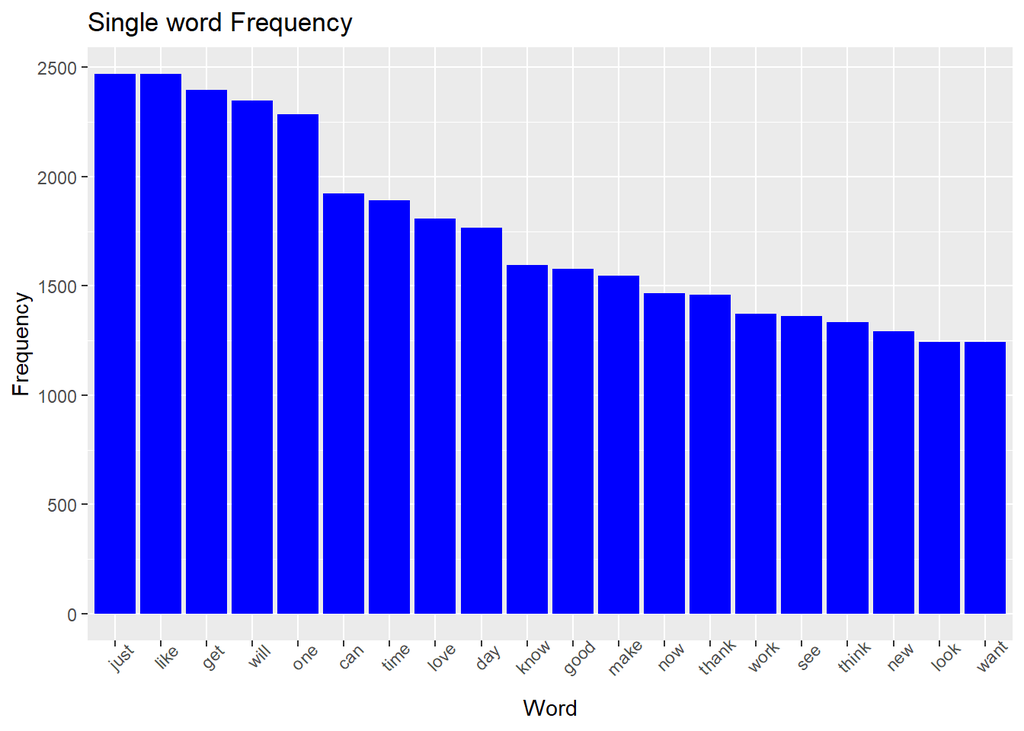

```r
g1 <- ggplot(single_df[1:20,],aes(x=reorder(term, -freq),y=freq))+ geom_bar(stat="identity", fill = "blue")
g1 <- g1 + theme(axis.text.x=element_text(angle=45))
g1 <- g1 + labs(title="Single word Frequency",x="Word",y="Frequency")
g1
```

The top 20 fequently used biwords phases are shown as below:

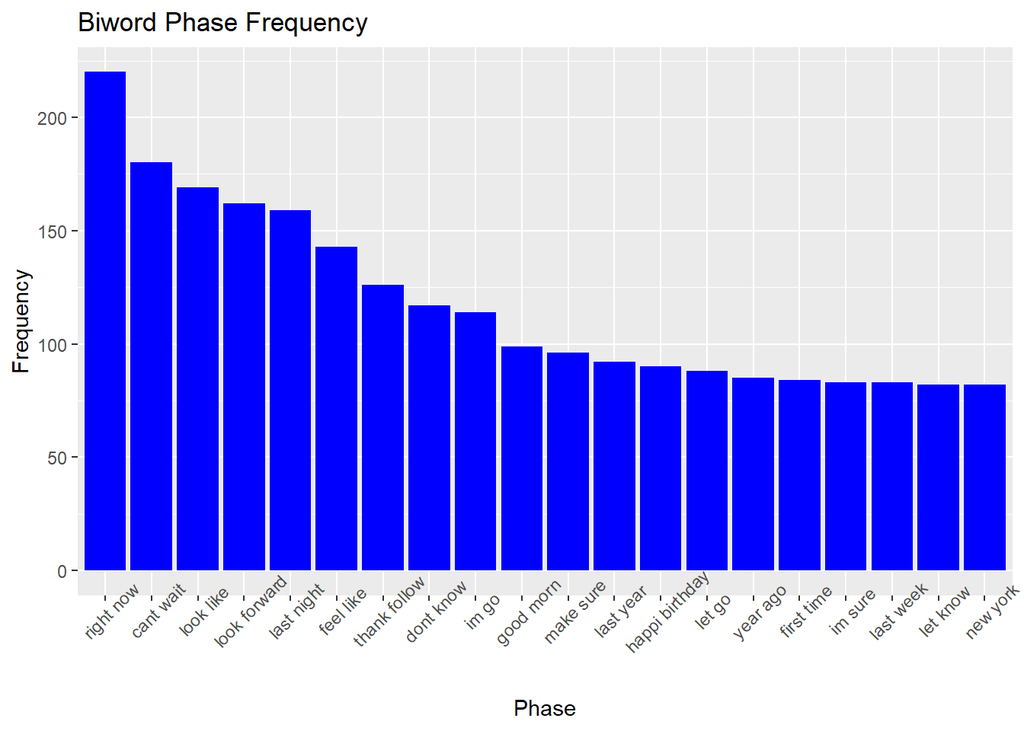

```r
g2 <- ggplot(bi_df[1:20,],aes(x=reorder(term, -freq),y=freq))+ geom_bar(stat="identity", fill = "blue")
g2 <- g2 + theme(axis.text.x=element_text(angle=45))
g2 <- g2 + labs(title="Biword Phase Frequency",x="Phase",y="Frequency")
g2
```

The top 20 fequently used triwords phases are shown as below:

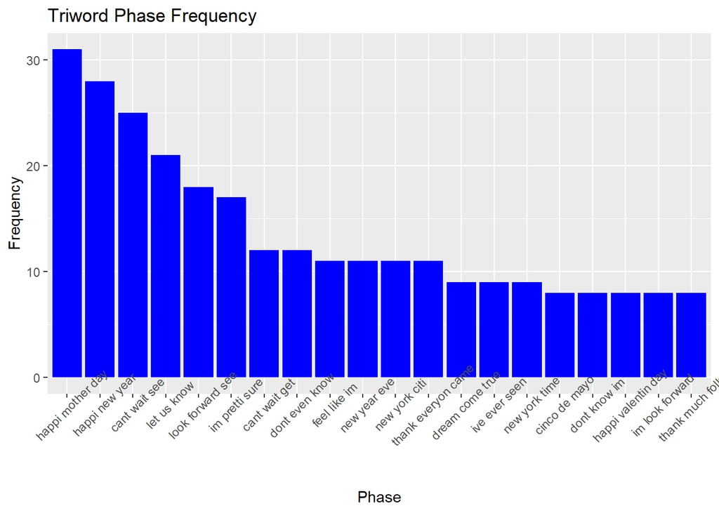

```r
g3 <- ggplot(tri_df[1:20,],aes(x=reorder(term, -freq),y=freq))+ geom_bar(stat="identity", fill = "blue")
g3 <- g3 + theme(axis.text.x=element_text(angle=45))
g3 <- g3 + labs(title="Triword Phase Frequency",x="Phase",y="Frequency")
g3
```